# PS5

Reena

2023-02-19

## Load and Check Data

2. (2pt) Load data. How many rows/columns do we have?

```
## [1] 13055
```

```
## [1] 25
```

*There are 13055 rows, 25 columns.*

3. (2pt) Print a small sample of data. Does it look OK?

```r
rand_rows <- sample(nrow(data), 5)
data[rand_rows, ]
```

```
##       iso3                       name iso2   region
## 3103   DMA                   Dominica   DM Americas
## 6191   KIR                   Kiribati   KI  Oceania
## 10599  SOM                    Somalia   SO   Africa
## 7844   MMR                    Myanmar   MM     Asia
## 7176   MAF Saint Martin (French part)   MF Americas
##                            sub.region intermediate.region time totalPopulation
## 3103  Latin America and the Caribbean           Caribbean 1991           70374
## 6191                       Micronesia                     2010          102927
## 10599              Sub-Saharan Africa      Eastern Africa 1969         3386738
## 7844               South-eastern Asia                     1983        36491800
## 7176  Latin America and the Caribbean           Caribbean 1975            6881
##       fertilityRate lifeExpectancy childMortality youthFemaleLiteracy
## 3103             NA             NA           16.2                  NA
## 6191          3.843         65.769           64.5                  NA
```

[output cut: 21 more lines]

*It looks fine.*

## Descriptive Statistics

1. (3pt) How many countries are there in the dataset? Analyze all three: iso3, iso2 and name.

```r
length(unique(data$iso2))
```

```
## [1] 249
```

```r
length(unique(data$name))
```

```
## [1] 250
```

```r
length(unique(data$iso3))
```

```
## [1] 253
```

*It looks like there are 253 iso3, 249 iso2, and 250 names.*

2. If you did this correctly, you saw that there are more names than iso-2 codes, and there are even more iso3 -codes. What is going on? Can you find it out?
1. (5pt) Find how many names are there for each iso-2 code. Are there any iso-2 codes that correspond to more than one name? What are these countries?
2. (5pt) Now repeat the same for name and iso3-code. Are there country names that have more than one iso3-code? What are these countries?

```r
countries <- unique(data[, c("name", "iso2", "iso3")])
```

*It looks like some iso3 names has missing iso2 and names. Namibia does not have a corresponding iso2.*

```r
iso2names <- data %>%
  group_by(iso2) %>%
  summarise(num = n_distinct(name))
```

*Looks like there is no iso2 codes that correspond to more than one name. However, there are two blank iso2 lines.*

```r
iso3names <- data %>%
  group_by(name) %>%
  summarise(num = n_distinct(iso3))
```

*There are 4 blank lines. Looks like below four countries have alternative names:* *1988, Cocos (Keeling) Islands, CCK/CHANISL* *3974, Gabon, GAB/GBM* *6261, Republic of Korea, KOR/KOS* *8666, Netherlands, NLD/NLD CURACAO*

3. (2pt) What is the minimum and maximum year in these data?

```r
cleaned_data <- data[complete.cases(data$time),]
max(cleaned_data$time)
```

```
## [1] 2019
```

```r
min(cleaned_data$time)
```

```
## [1] 1960
```

*Excluding the NA values, the maximum year is 2019 and the minimum year is 1960.*

## CO2 Emissions

1. (2pt) How many missing co2 emissions are there for each year? Analyze both missing CO2 and co2_PC. Which years have most missing data?

```r
sum(is.na(data$co2))
```

```
## [1] 2658
```

```r
sum(is.na(data$co2_PC))
```

```
## [1] 2661
```

*There are 2658 missing data for co2 and 2661 missing data for co2_PC。*

```r
missing_counts <- data %>%
  group_by(time) %>%
  summarise(co2_missing = sum(is.na(data$co2)),
            co2_pc_missing = sum(is.na(data$co2_PC)))

most_missing_co2 <- missing_counts[which.max(missing_counts$co2_missing), "time"]
most_missing_co2_pc <- missing_counts[which.max(missing_counts$co2_pc_missing), "time"]

most_missing_co2
```

```
## # A tibble: 1 × 1
##    time
##   <int>
## 1  1960
```

```r
most_missing_co2_pc
```

```
## # A tibble: 1 × 1
##    time
##   <int>
## 1  1960
```

2. (5pt) Make a plot of total CO2 emissions over time for the U.S, China, and India. Add a few more countries of your choice. Explain what do you see.

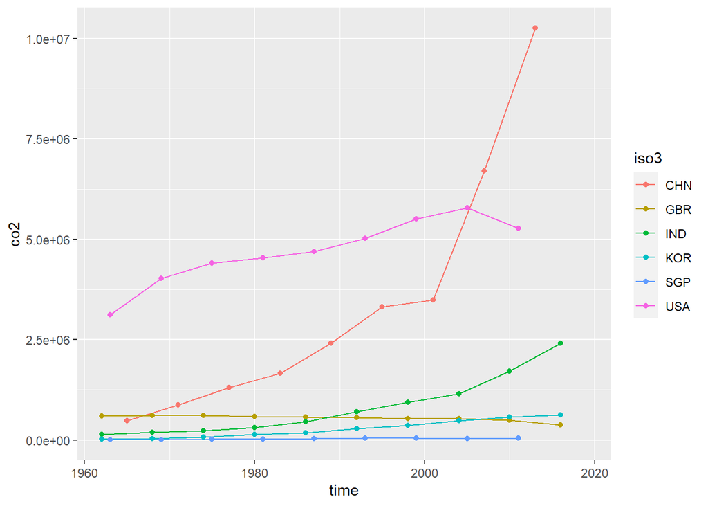

```r
data %>%
  filter(iso3 ==c( "USA", "CHN", "IND",  "GBR", "KOR", "SGP")) %>%
  ggplot()+
  geom_line(aes(x=time, y = co2, col=iso3))+
  geom_point(aes(x=time, y = co2, col=iso3))
```

*This is a plot of total CO2 emissions over time for the U.S, China, India, Korea, Great Britain,* *and Singapore. I found that the CO2 emission of USA and China are significantly high no matter* *who they compared to.*

3. (5pt) Now let’s analyze the CO2 emissions per capita (co2_PC). Make a similar plot of the same countries. What does this figure suggest?

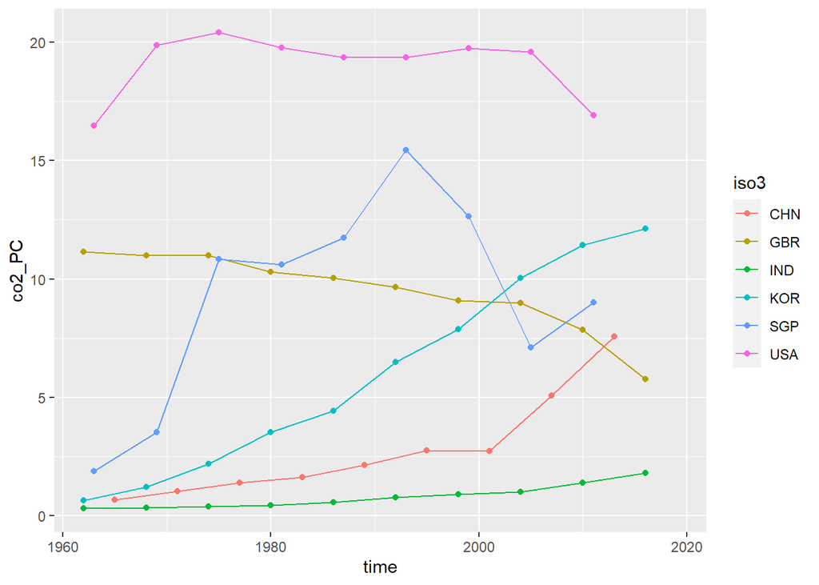

```r
data %>%
  filter(iso3 ==c( "USA", "CHN", "IND",  "GBR", "KOR", "SGP")) %>%
  ggplot()+
  geom_line(aes(x=time, y = co2_PC, col=iso3))+
  geom_point(aes(x=time, y = co2_PC, col=iso3))
```

*This is a plot for CO2 per capita for these countries. I can see that the US is very high* *for CO2 emissions per capita. It does not even intersect with other countries. China’s CO2* *emissions per capita is actually lower than a lot other countries, but still higher than that* *of India.*

4. (6pt) Compute average CO2 emissions per capita across the continents (assume region is the same as continent). Comment what do you see.

```r
ave_co2_pc_region_2016 <- data %>%
  filter(time == 2016) %>%
  group_by(region) %>%
  summarize(ave_co2_pc = mean(co2_PC, na.rm = TRUE))
ave_co2_pc_region_2016$time <- 2016
ave_co2_pc_region_2016 <- ave_co2_pc_region_2016 %>%
  filter(ave_co2_pc != 19.396490)
ave_co2_pc_region_2016
```

```
## # A tibble: 5 × 3
##   region   ave_co2_pc  time
##   <chr>         <dbl> <dbl>
## 1 Africa         1.20  2016
## 2 Americas       4.80  2016
## 3 Asia           6.47  2016
## 4 Europe         6.64  2016
## 5 Oceania        4.57  2016
```

```r
ave_co2_pc_region_1960 <- data %>%
  filter(time == 1960) %>%
  group_by(region) %>%
  summarize(ave_co2_pc = mean(co2_PC, na.rm = TRUE))
ave_co2_pc_region_1960$time <- 1960
ave_co2_pc_region_1960 <- na.omit(ave_co2_pc_region_1960)
ave_co2_pc_region_1960
```

```
## # A tibble: 5 × 3
##   region   ave_co2_pc  time
##   <chr>         <dbl> <dbl>
## 1 Africa        0.291  1960
## 2 Americas      7.15   1960
## 3 Asia          1.74   1960
## 4 Europe        5.77   1960
## 5 Oceania       2.73   1960
```

5. (7pt) Make a barplot where you show the previous results–average CO2 emissions per capita across continents in 1960 and 2016.

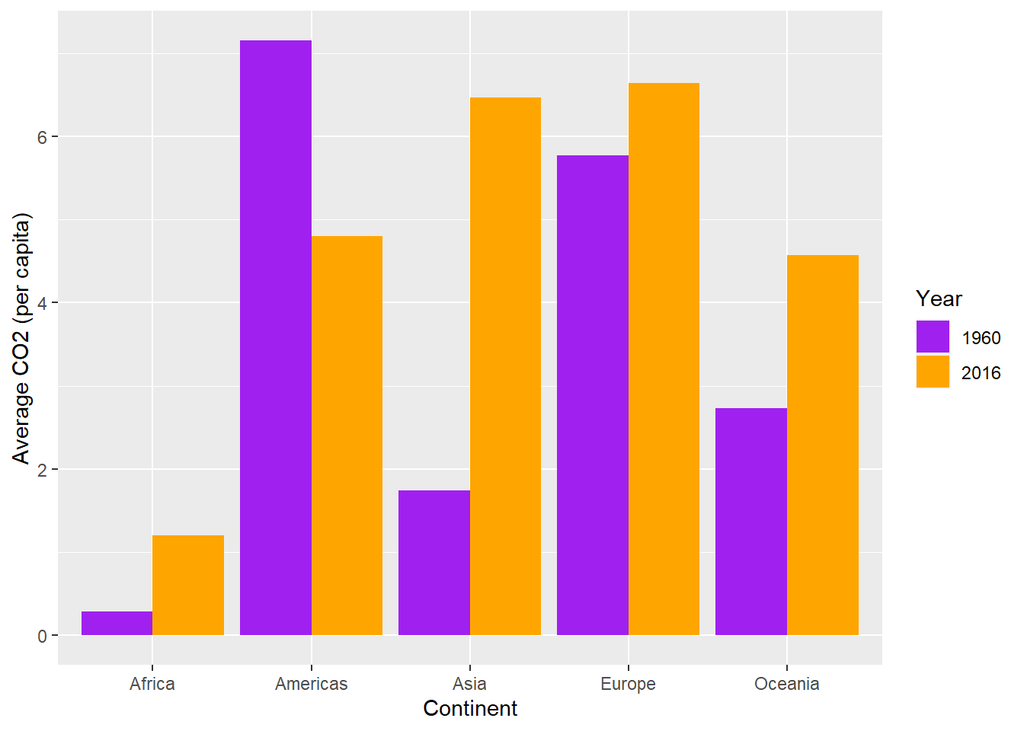

```r
ave_co2_pc_comb <- rbind(ave_co2_pc_region_1960, ave_co2_pc_region_2016)
ggplot(ave_co2_pc_comb, aes(x = region, y = ave_co2_pc, fill = factor(time))) +
  geom_bar(stat = "identity", position = "dodge") +
  scale_fill_manual(values = c("purple", "orange")) +
  labs(x = "Continent", y = "Average CO2 (per capita)", fill = "Year")
```

*Here is a plot for average CO2 emissions per capita across continents in 1960 and 2016.*

6. Which countries are the three largest, and three smallest CO2 emitters (in terms of CO2 per capita) in 2019 for each continent? (Assume region is continent).

```r
data_filtered <- data %>% filter(!is.na(co2_PC))
data_filtered_summary <- data_filtered %>% filter(time == 2016) %>%
  group_by(region) %>%
  slice_max(order_by = co2_PC, n = 3) %>%
  bind_rows(data_filtered %>% filter(time == 2016) %>%
              group_by(region) %>%
              slice_min(order_by = co2_PC, n = 3))
```

*The largest 3 CO2 emitters:* *Africa：South Africa, Libya, Seychelles* *Americas: Trinidad and Tobago, USA, Canada* *Asia: Qatar, Kuwait, Bahrain* *Europe: Gibraltar, Luxembourg, Faroe Islands* *Oceania: New Caledonia, Australia, Palau*

*The smallest 3 CO2 emitters:* *Africa: Congo, Somalia, Burundi* *Americas: Haiti, Nicaragua, Honduras* *Asia: Afghanistan, Nepal, Yemen* *Europe: Liechtenstein, Albania, Republic of Moldova.* *Oceania: Solomon Islands, Vanuatu, Kiribati*

## GDP per capita

1. (8pt) Make a scatterplot of GDP per capita versus life expectancy by country, using data for
2. Make the point size dependent on the country size, and color those according to the continent.

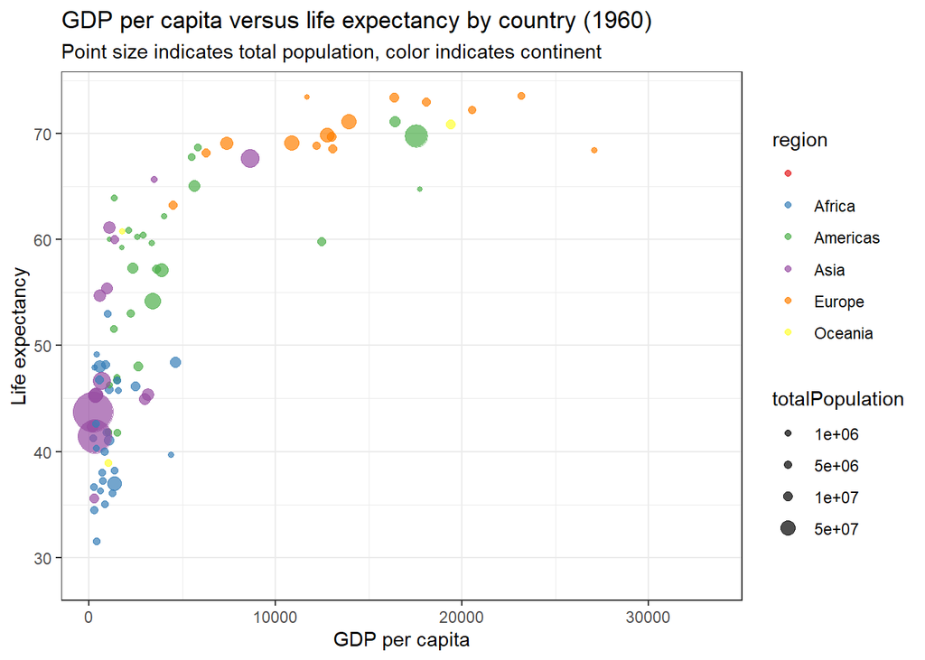

```r
data_1960 <- data %>% filter(time == 1960)
ggplot(data_1960, aes(x = GDP_PC, y = lifeExpectancy, size = totalPopulation, color = region)) +
  geom_point(alpha=0.7) +
  scale_color_brewer(type = "qual", palette = "Set1") +
  scale_size_continuous(range = c(1, 10), breaks = c(1000000, 5000000, 10000000, 50000000)) +
  xlab("GDP per capita") +
  ylab("Life expectancy") +
  labs(title = "GDP per capita versus life expectancy by country (1960)",
       subtitle = "Point size indicates total population, color indicates continent") +
  theme_bw()
```

*Here is a scatterplot of GDP per capita versus life expectancy by country in 1960. Europe has relatively high* *life expectancy. Asia has a lot of people but lower life expectancy. The Americas are in between Asia and Europe.* *The higher the GDP per capita, the higher the life expectancy.*

2. (4pt) Make a similar plot, but this time use 2019 data only.

[figure not shown]

```r
data_1960 <- data %>% filter(time == 2019)
ggplot(data_1960, aes(x = GDP_PC, y = lifeExpectancy, size = totalPopulation, color = region)) +
  geom_point(alpha=0.7) +
  scale_color_brewer(type = "qual", palette = "Set1") +
  scale_size_continuous(range = c(1, 10), breaks = c(1000000, 5000000, 10000000, 50000000)) +
  xlab("GDP per capita") +
  ylab("Life expectancy") +
  labs(title = "GDP per capita versus life expectancy by country (2016)",
       subtitle = "Point size indicates total population, color indicates continent") +
  theme_bw()
```

3. (6pt) Compare these two plots and comment what do you see. How has world developed through the last 60 years?

*Africa did not make so much progress. Asia’s life expectancy went up,* *some Asia countries move to the top with Americas and Europe.* *GDP per capita still seems to correlate with life expectancy.* *Overall in the past 60 years, GDP per capita went up significantly, but* *how the GDP is distributed between continents did not change too much.* *Africa is still at the bottom, Americas and Europe are still at top.*

4. (6pt) Compute the average life expectancy for each continent in 1960 and 2019. Do the results fit with what do you see on the figures?

```r
avg_lifeexp_1960 <- data %>%
  filter(time == 1960) %>%
  group_by(region) %>%
  summarize(avg_lifeexp = mean(lifeExpectancy, na.rm = TRUE))
avg_lifeexp_1960
```

```
## # A tibble: 6 × 2
##   region     avg_lifeexp
##   <chr>            <dbl>
## 1 ""                70.7
## 2 "Africa"          41.5
## 3 "Americas"        58.6
## 4 "Asia"            51.6
## 5 "Europe"          68.3
## 6 "Oceania"         56.4
```

```r
# Compute average life expectancy by continent in 2019
avg_lifeexp_2019 <- data %>%
  filter(time == 2019) %>%
  group_by(region) %>%
  summarize(avg_lifeexp = mean(lifeExpectancy, na.rm = TRUE))
avg_lifeexp_2019
```

```
## # A tibble: 6 × 2
##   region     avg_lifeexp
##   <chr>            <dbl>
## 1 ""                77.8
## 2 "Africa"          64.1
## 3 "Americas"        75.8
## 4 "Asia"            74.6
## 5 "Europe"          79.4
## 6 "Oceania"         73.5
```

*Yes, it is consistent with what I see on figures.*

5. (8pt) Compute the average LE growth from 1960-2019 across the continents. Show the results in the order of growth. Explain what do you see.

```r
growth <- data %>%
  group_by(region) %>%
  mutate(growth = (lifeExpectancy -
  lag(lifeExpectancy))/lag(lifeExpectancy)) %>%
  filter(time > 1960 & time < 2019) %>%
  summarize(avg_growth = mean(growth, na.rm=TRUE)) %>%
  arrange(desc(avg_growth))
growth
```

```
## # A tibble: 6 × 2
##   region     avg_growth
##   <chr>           <dbl>
## 1 "Africa"      0.00749
## 2 "Asia"        0.00656
## 3 "Oceania"     0.00467
## 4 "Americas"    0.00441
## 5 ""            0.00268
## 6 "Europe"      0.00258
```

*The growth is the highest in Africa. Since Europe’s LE is already high, there is probably not a* *lot of capacity for them to grow further.*

6. (6pt) Show the histogram of GDP per capita for years of 1960 and 2019. Try to put both histograms on the same graph, see how well you can do it!

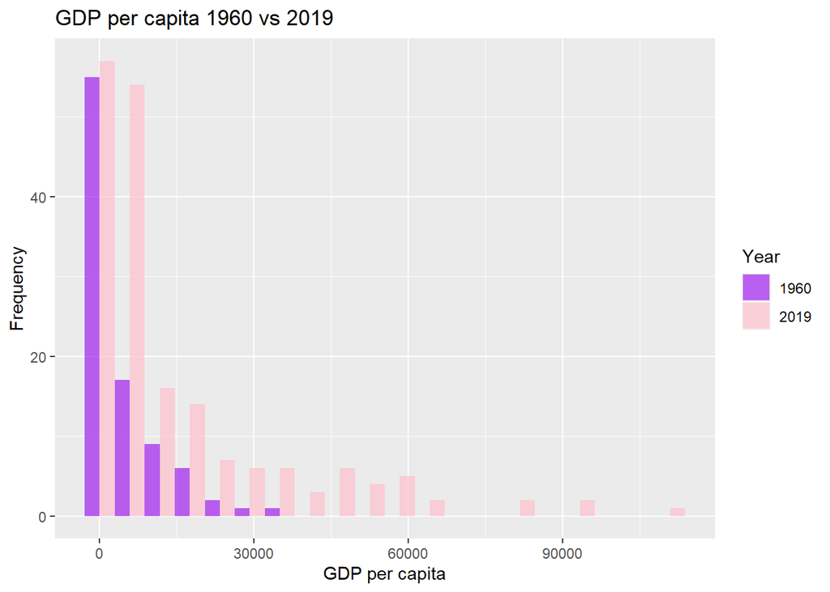

```r
GDP_1960_2019 <- data %>%
  filter(time %in% c(1960, 2019))

ggplot(GDP_1960_2019, aes(x = GDP_PC, fill = factor(time))) +
  geom_histogram(position = "dodge", alpha = 0.7, bins = 20) +
  scale_fill_manual(values = c("purple", "pink"), name = "Year") +
  labs(title = "GDP per capita 1960 vs 2019", x =
         "GDP per capita", y = "Frequency")
```

*Here is the histogram of GDP per capita for years of 1960 and 2019.*

7. (6pt) What was the ranking of US in terms of life expectancy in 1960 and in 2019? (When counting from top.)

```r
rank_1960 <- data %>%
  filter(time == 1960) %>%
  arrange(desc(lifeExpectancy)) %>%
  mutate(rank = rank(-lifeExpectancy, na.last = "keep")) %>%
  filter(name == "United States of America")
rank_1960
```

```
##   iso3                     name iso2   region       sub.region
## 1  USA United States of America   US Americas Northern America
##   intermediate.region time totalPopulation fertilityRate lifeExpectancy
## 1                     1960       180671000         3.654       69.77073
##   childMortality youthFemaleLiteracy youthMaleLiteracy adultLiteracy   GDP_PC
## 1           30.1                  NA                NA            NA 17562.67
##   accessElectricity agriculturalLand agricultureTractors cerealProduction
## 1                NA               NA                  NA               NA
##   fertilizerHa     co2 greenhouseGases   co2_PC pm2.5_35 battleDeaths rank
## 1           NA 2890696              NA 15.99978       NA           NA   18
```

```r
rank_2019 <- data %>%
  filter(time == 2019) %>%
  arrange(desc(lifeExpectancy)) %>%
  mutate(rank = rank(-lifeExpectancy, na.last = "keep")) %>%
  filter(name == "United States of America")
rank_2019
```

```
##   iso3                     name iso2   region       sub.region
## 1  USA United States of America   US Americas Northern America
##   intermediate.region time totalPopulation fertilityRate lifeExpectancy
## 1                     2019       328239523         1.705        78.7878
##   childMortality youthFemaleLiteracy youthMaleLiteracy adultLiteracy   GDP_PC
## 1            6.5                  NA                NA            NA 55753.14
##   accessElectricity agriculturalLand agricultureTractors cerealProduction
## 1               100               NA                  NA               NA
##   fertilizerHa co2 greenhouseGases co2_PC pm2.5_35 battleDeaths rank
## 1           NA  NA              NA     NA       NA           NA   47
```

*The ranking is 18 in 1960 and 47 in 2019.*

8. (6pt) If you did this correctly, then you noticed that US ranking has been falling quite a bit. But we also have more countries in 2019–what about the relative rank divided by the corresponding number of countries that have LE data in the corresponding year?

```r
n_countries_1960 <- data %>%
  filter(time == 1960 & !is.na(lifeExpectancy)) %>%
  nrow()
rank_1960$rank/n_countries_1960
```

```
## [1] 0.0952381
```

```r
n_countries_2019 <- data %>%
  filter(time == 2019 & !is.na(lifeExpectancy)) %>%
  nrow()
rank_2019$rank/n_countries_2019
```

```
## [1] 0.2373737
```

*I got 0.0952381 for 1960 and 0.2373737 for 2019. Slightly different from the hint.* *Looks like the US is still falling significantly even with the relative rank.*

# It took me 7 hours to do this homework.